# ES207_HW8

### 1. Push all of your functions from this entire homework as separate function (.R) files with intelligible titles to a new GitHub repo titled es_207_hw8. Turn all of your other work in as .html notebook in catcourses.

https://github.com/ebolch/es207_hw8

### 2. Complete the tutorial steps for Strings from Chapter 14 in your R for Data Science text book http://r4ds.had.co.nz/strings.html. Answer excercises: 14.2.5 #3, #4, #5, #6; 14.3.1.1 #3; 14.3.3.1 #1; 14.3.4.1 #2; 14.4.3.1 #2; 14.4.4.1 #1; 14.4.5.1 #1, #2; 14.5.1 #2; Make sure to show all of your work in a code notebook.

#### 14.2.5 #3 Use str_length() and str_sub() to extract the middle character from a string. What will you do if the string has an even number of characters?

```r
blah <- "blahh"
str_length(blah)
```

```
## [1] 5
```

```r
str_sub(blah, start = (str_length(blah)/2)+1,end = (str_length(blah)/2)+1)
```

```
## [1] "a"
```

```r
#
```

If the string has an even number of characters the character 1 closer to the end will be returned.

#### 4 What does str_wrap() do? When might you want to use it?

Str_wrap takes a block of text and word wraps it based upon a decided character width.This might come in handy for formatting documents published in markdown.

#### 5 What does str_trim() do? What’s the opposite of str_trim()?

Str_trim removes whitespace at the beginnning and ends of lines of text. Str_pad does the opposite, adding extra space to the specified side of the string.

```r
str_trim(" abc ")
```

```
## [1] "abc"
```

```r
str_trim(" abc ", side = "left")
```

```
## [1] "abc "
```

```r
str_trim(" abc ", side = "right")
```

```
## [1] " abc"
```

```r
str_pad("abc", 4, side = "both")
```

```
## [1] "abc "
```

```r
str_pad("abc", 4, side = "right")
```

```
## [1] "abc "
```

```r
str_pad("abc", 4, side = "left")
```

```
## [1] " abc"
```

#### 6. Write a function that turns (e.g.) a vector c(“a”, “b”, “c”) into the string a, b, and c. Think carefully about what it should do if given a vector of length 0, 1, or 2.

```r
mergec <- function(x, delim = ",") {
  n <- length(x)
  if (n == 0) {
    ""
  } else if (n == 1) {
    x
  } else if (n == 2) {
    # no comma before and when n == 2
    str_c(x[[1]], "and", x[[2]], sep = " ")
  } else {
    # commas after all n - 1 elements
    not_last <- str_c(x[seq_len(n - 1)], delim)
    # prepend "and" to the last element
    last <- str_c("and", x[[n]], sep = " ")
    # combine parts with spaces
    str_c(c(not_last, last), collapse = " ")
  }
}
mergec("a")
```

```
## [1] "a"
```

```r
mergec(c("a", "b"))
```

```
## [1] "a and b"
```

```r
mergec(c("a", "b", "c"))
```

```
## [1] "a, b, and c"
```

```r
mergec(c("a", "b", "c", "d"))
```

```
## [1] "a, b, c, and d"
```

#### 14.3.1.1 #3 What patterns will the regular expression `\..\..\..` match? How would you represent it as a string?

The regular expression `\..\..\..`will match a pattern consisting of a dot followed by a character repeated 3 times, it would appear as something like .a.b.c.

#### 14.3.3.1 #1 Create regular expressions to find all words that: Start with a vowel.That only contain consonants. (Hint: thinking about matching “not”-vowels.) End with ed, but not with eed.End with ing or ise.

```r
wrds <- c("ate","why", "deed", "coded", "coding", "wise")
#Vowel
str_subset(wrds, "^[aeiou]")
```

```
## [1] "ate"
```

```r
#Consonants
str_subset(wrds, "^[^aeiou]+$")
```

```
## [1] "why"
```

```r
#end with "ed" not "eed"
str_subset(wrds, "[^e]ed$")
```

```
## [1] "coded"
```

```r
#end with ing or ise
str_subset(wrds, "i(ng|se)$")
```

```
## [1] "coding" "wise"
```

#### 14.3.4.1 #2 Describe, in words, what these expressions will match:

1. `^.*$` - Will match any string
2. `\\{.+\\}` - Will match any string surrounded by {}
3. `\d{4}-\d{2}-\d{2}` - Will match 4digits-2digits-2digits,like a date 2020-03-23.
4. `\\\\{4}` - Will match 4 backslashes

#### 14.4.3.1 #2 Find all contractions. Separate out the pieces before and after the apostrophe.

```r
contraction <- "([A-Za-z]+)'([A-Za-z]+)"
sentences[str_detect(sentences, contraction)] %>%
  str_extract(contraction) %>%
  str_split("'")
```

```
## [[1]]
## [1] "It" "s"
##
## [[2]]
## [1] "man" "s"
##
## [[3]]
## [1] "don" "t"
##
## [[4]]
## [1] "store" "s"
##
## [[5]]
## [1] "workmen" "s"
##
## [[6]]
## [1] "Let" "s"
##
## [[7]]
## [1] "sun" "s"
##
## [[8]]
## [1] "child" "s"
##
## [[9]]
## [1] "king" "s"
##
## [[10]]
## [1] "It" "s"
##
## [[11]]
## [1] "don" "t"
##
## [[12]]
## [1] "queen" "s"
##
## [[13]]
## [1] "don" "t"
##
## [[14]]
## [1] "pirate" "s"
##
## [[15]]
## [1] "neighbor" "s"
```

#### 14.4.4.1 #1 Replace all forward slashes in a string with backslashes.

```r
str_replace_all("c:/file/loc", "/", "\\\\")
```

```
## [1] "c:\\file\\loc"
```

#### 14.4.5.1 #1 Split up a string like “apples, pears, and bananas” into individual components.

```r
apb<-c("apples, pears, and bananas")
apb
```

```
## [1] "apples, pears, and bananas"
```

```r
str_split(apb, ",+(and +)?")[[1]]
```

```
## [1] "apples"       " pears"       " and bananas"
```

#### 2 Why is it better to split up by boundary(“word”) than " "?

Word boundary is better than a space because it recognizes non-space punctuation that splits words, but also recognizes things such as contractions as words.

#### 14.5.1 #2 What are the five most common words in sentences?

```r
tibble(word = unlist(str_extract_all(sentences, boundary("word")))) %>% #words
  mutate(word = str_to_lower(word)) %>% #lower case for counting duplicates
  count(word, sort = TRUE) %>% #Count
  head(5)#Top5
```

```
## # A tibble: 5 x 2
##   word      n
##   <chr> <int>
## 1 the     751
## 2 a       202
## 3 of      132
## 4 to      123
## 5 and     118
```

## Data Wrangling - CA Air Quality

```r
require(readr)
require(readxl)
o3.filepaths <- list.files("data/ca_ozone/", "\\.txt$", full.names = TRUE)
o3.filenames <- list.files("data/ca_ozone/", pattern = ".txt") # check your dirs
o3.filenames
```

```
##  [1] "ozone19801984-1.txt" "ozone19801984.txt"   "ozone19851989-1.txt"
##  [4] "ozone19851989.txt"   "ozone19901994.txt"   "ozone19951999.txt"
##  [7] "ozone20002004.txt"   "ozone20052009-1.txt" "ozone20052009.txt"
## [10] "ozone20102011.txt"
```

```r
o3.filelist <- lapply(o3.filepaths, read_delim, delim = "|")
names(o3.filelist) <- gsub(".txt","", o3.filenames)
o3.filelist
```

```
## $`ozone19801984-1`
## # A tibble: 5,133,781 x 4
##     site date       start_hour   obs
##    <dbl> <date>          <dbl> <dbl>
##  1  2001 1980-02-01          0  0.02
##  2  2001 1980-02-01          1  0.01
##  3  2001 1980-02-01          2  0
##  4  2001 1980-02-01          3  0
##  5  2001 1980-02-01          4  0
##  6  2001 1980-02-01          5  0
##  7  2001 1980-02-01          6  0
##  8  2001 1980-02-01          7  0.01
##  9  2001 1980-02-01          8  0
## 10  2001 1980-02-01          9  0.01
## # ... with 5,133,771 more rows
##
## $ozone19801984
## # A tibble: 5,133,781 x 4
##     site date       start_hour   obs
##    <dbl> <date>          <dbl> <dbl>
##  1  2001 1980-02-01          0  0.02
##  2  2001 1980-02-01          1  0.01
##  3  2001 1980-02-01          2  0
##  4  2001 1980-02-01          3  0
##  5  2001 1980-02-01          4  0
##  6  2001 1980-02-01          5  0
##  7  2001 1980-02-01          6  0
##  8  2001 1980-02-01          7  0.01
##  9  2001 1980-02-01          8  0
## 10  2001 1980-02-01          9  0.01
## # ... with 5,133,771 more rows
##
## $`ozone19851989-1`
## # A tibble: 5,819,182 x 4
##     site date       start_hour   obs
##    <dbl> <date>          <dbl> <dbl>
##  1  2001 1985-01-01          0  0.01
##  2  2001 1985-01-01          1  0.01
##  3  2001 1985-01-01          2  0
##  4  2001 1985-01-01          3  0.01
```

[output cut: 104 more lines]

```
## $ozone20102011
## # A tibble: 2,755,156 x 4
##     site date       start_hour   obs
##    <dbl> <date>          <dbl> <dbl>
##  1  2008 2010-01-01          0 0.021
##  2  2008 2010-01-01          2 0.022
##  3  2008 2010-01-01          3 0.022
##  4  2008 2010-01-01          4 0.021
##  5  2008 2010-01-01          5 0.02
##  6  2008 2010-01-01          6 0.021
##  7  2008 2010-01-01          7 0.021
##  8  2008 2010-01-01          8 0.025
##  9  2008 2010-01-01          9 0.029
## 10  2008 2010-01-01         10 0.029
## # ... with 2,755,146 more rows
```

### 3. What class is o3.filelist? What does it contain?

o3.filelist is of class list, and it contains a list of 10 tibbles. Each tibble has the data contained within one of the text files.

### 5. Rewrite the code above using the stringr package insead of grep{base}.

```r
names(o3.filelist) == str_sub(o3.filenames,1,-5) #Check if they match
```

```
##  [1] TRUE TRUE TRUE TRUE TRUE TRUE TRUE TRUE TRUE TRUE
```

## Summarizing Real World Data

```r
o3summarize <- function(x){
  out <- group_by(x, site = as.factor(site), date) %>%
  summarize(o3 = mean(obs, na.rm = TRUE))
}
# now apply my function to the list of tibbles
daily <- o3.filelist %>%
  map(o3summarize)
daily
```

```
## $`ozone19801984-1`
## # A tibble: 222,324 x 3
## # Groups:   site [225]
##    site  date            o3
##    <fct> <date>       <dbl>
##  1 2001  1980-02-01 0.00652
##  2 2001  1980-02-02 0.00826
##  3 2001  1980-02-03 0.00565
##  4 2001  1980-02-04 0.00783
##  5 2001  1980-02-05 0.001
##  6 2001  1980-02-07 0.00222
##  7 2001  1980-02-08 0.00867
##  8 2001  1980-02-11 0.0178
##  9 2001  1980-02-12 0.0162
## 10 2001  1980-02-13 0.0154
## # ... with 222,314 more rows
##
## $ozone19801984
## # A tibble: 222,324 x 3
## # Groups:   site [225]
##    site  date            o3
##    <fct> <date>       <dbl>
##  1 2001  1980-02-01 0.00652
##  2 2001  1980-02-02 0.00826
##  3 2001  1980-02-03 0.00565
##  4 2001  1980-02-04 0.00783
##  5 2001  1980-02-05 0.001
##  6 2001  1980-02-07 0.00222
##  7 2001  1980-02-08 0.00867
##  8 2001  1980-02-11 0.0178
##  9 2001  1980-02-12 0.0162
## 10 2001  1980-02-13 0.0154
## # ... with 222,314 more rows
##
## $`ozone19851989-1`
## # A tibble: 255,582 x 3
## # Groups:   site [210]
##    site  date            o3
##    <fct> <date>       <dbl>
##  1 2001  1985-01-01 0.0170
```

[output cut: 114 more lines]

```
## # A tibble: 121,548 x 3
## # Groups:   site [187]
##    site  date           o3
##    <fct> <date>      <dbl>
##  1 2008  2010-01-01 0.0246
##  2 2008  2010-01-02 0.0315
##  3 2008  2010-01-03 0.0327
##  4 2008  2010-01-04 0.0294
##  5 2008  2010-01-05 0.0277
##  6 2008  2010-01-06 0.0286
##  7 2008  2010-01-07 0.0247
##  8 2008  2010-01-08 0.0232
##  9 2008  2010-01-09 0.0270
## 10 2008  2010-01-10 0.0298
## # ... with 121,538 more rows
```

### 6. Summarize the o3 data above by site and by month and by year using a piping operator (That is, find the monthly mean o3 for each site for each year).

```r
o3summarize_monthly <- function(x){
  x$yr<- str_extract(x$date,"\\d{4}")
  x$mon <- str_sub(x$date, 6,-4)

  out <- group_by(x, site = as.factor(site), Year = as.factor(yr), Month = as.factor(mon)) %>%
  summarize(o3 = mean(obs, na.rm = TRUE))
}
# now apply my function to the list of tibbles
monthly <- o3.filelist %>%
  map(o3summarize_monthly)
monthly
```

```
## $`ozone19801984-1`
## # A tibble: 7,579 x 4
## # Groups:   site, Year [744]
##    site  Year  Month     o3
##    <fct> <fct> <fct>  <dbl>
##  1 2001  1980  02    0.0185
##  2 2001  1980  03    0.0157
##  3 2001  1980  04    0.0251
##  4 2001  1980  05    0.0266
##  5 2001  1980  06    0.0268
##  6 2001  1980  07    0.0345
##  7 2001  1980  08    0.0337
##  8 2001  1980  09    0.0266
##  9 2001  1980  10    0.0256
## 10 2001  1980  11    0.0141
## # ... with 7,569 more rows
##
## $ozone19801984
## # A tibble: 7,579 x 4
## # Groups:   site, Year [744]
##    site  Year  Month     o3
##    <fct> <fct> <fct>  <dbl>
##  1 2001  1980  02    0.0185
##  2 2001  1980  03    0.0157
##  3 2001  1980  04    0.0251
##  4 2001  1980  05    0.0266
##  5 2001  1980  06    0.0268
##  6 2001  1980  07    0.0345
##  7 2001  1980  08    0.0337
##  8 2001  1980  09    0.0266
##  9 2001  1980  10    0.0256
## 10 2001  1980  11    0.0141
## # ... with 7,569 more rows
##
## $`ozone19851989-1`
## # A tibble: 8,655 x 4
## # Groups:   site, Year [812]
##    site  Year  Month     o3
##    <fct> <fct> <fct>  <dbl>
##  1 2001  1985  01    0.0135
```

[output cut: 114 more lines]

```
## # A tibble: 4,070 x 4
## # Groups:   site, Year [361]
##    site  Year  Month     o3
##    <fct> <fct> <fct>  <dbl>
##  1 2008  2010  01    0.0296
##  2 2008  2010  02    0.0321
##  3 2008  2010  03    0.0392
##  4 2008  2010  04    0.0369
##  5 2008  2010  05    0.0349
##  6 2008  2010  06    0.0290
##  7 2008  2010  07    0.0260
##  8 2008  2010  08    0.0242
##  9 2008  2010  09    0.0299
## 10 2008  2010  10    0.0321
## # ... with 4,060 more rows
```

### 7. Ozone pollution actually follows a very strong diurnal pattern. How would you summarize the data from above in a better way to capture that diurnal pattern? Show me with your code.

```r
o3summarize_diurnal <- function(x){
  x$yr<- str_extract(x$date,"\\d{4}")
  x$mon <- str_sub(x$date, 6,-4)
  x$time <- ifelse(x$start_hour >= 7 & x$start_hour<= 19, "day", "night")

  out <- group_by(x, site = as.factor(site), Year = as.factor(yr), Month = as.factor(mon),Time = time) %>%
  summarize(o3 = mean(obs, na.rm = TRUE))
}

didaily <- o3.filelist %>%
  map(o3summarize_diurnal)
didaily
```

```
## $`ozone19801984-1`
## # A tibble: 15,158 x 5
## # Groups:   site, Year, Month [7,579]
##    site  Year  Month Time      o3
##    <fct> <fct> <fct> <chr>  <dbl>
##  1 2001  1980  02    day   0.0197
##  2 2001  1980  02    night 0.0172
##  3 2001  1980  03    day   0.0204
##  4 2001  1980  03    night 0.0108
##  5 2001  1980  04    day   0.0332
##  6 2001  1980  04    night 0.0162
##  7 2001  1980  05    day   0.0349
##  8 2001  1980  05    night 0.0161
##  9 2001  1980  06    day   0.0370
## 10 2001  1980  06    night 0.0138
## # ... with 15,148 more rows
##
## $ozone19801984
## # A tibble: 15,158 x 5
## # Groups:   site, Year, Month [7,579]
##    site  Year  Month Time      o3
##    <fct> <fct> <fct> <chr>  <dbl>
##  1 2001  1980  02    day   0.0197
##  2 2001  1980  02    night 0.0172
##  3 2001  1980  03    day   0.0204
##  4 2001  1980  03    night 0.0108
##  5 2001  1980  04    day   0.0332
##  6 2001  1980  04    night 0.0162
##  7 2001  1980  05    day   0.0349
##  8 2001  1980  05    night 0.0161
##  9 2001  1980  06    day   0.0370
## 10 2001  1980  06    night 0.0138
## # ... with 15,148 more rows
##
## $`ozone19851989-1`
## # A tibble: 17,309 x 5
## # Groups:   site, Year, Month [8,655]
##    site  Year  Month Time      o3
##    <fct> <fct> <fct> <chr>  <dbl>
##  1 2001  1985  01    day   0.0133
```

[output cut: 114 more lines]

```
## # A tibble: 8,140 x 5
## # Groups:   site, Year, Month [4,070]
##    site  Year  Month Time      o3
##    <fct> <fct> <fct> <chr>  <dbl>
##  1 2008  2010  01    day   0.0318
##  2 2008  2010  01    night 0.0266
##  3 2008  2010  02    day   0.0349
##  4 2008  2010  02    night 0.0284
##  5 2008  2010  03    day   0.0428
##  6 2008  2010  03    night 0.0343
##  7 2008  2010  04    day   0.0430
##  8 2008  2010  04    night 0.0288
##  9 2008  2010  05    day   0.0396
## 10 2008  2010  05    night 0.0286
## # ... with 8,130 more rows
```

```r
loc <- read_excel("data/ca_ozone/location.xls")
loc
```

```
## # A tibble: 921 x 36
##    Location  Site `Site Name` `Short Name` `AIRS Site` `AQD Site` County
##    <chr>    <dbl> <chr>       <chr>        <chr>       <chr>       <dbl>
##  1 2001      2001 Citrus Hei~ Citrus_Hghts 060670001   3400293        34
##  2 2007      2007 McCloud-Mi~ McCloud-Minn 060930002   4700867        47
##  3 2008      2008 El Capitan~ El_Capitan_B 060830008   4200370        42
##  4 2011      2011 Eureka-For~ Eureka-FtAve <NA>        1200522        12
##  5 2012      2012 Fresno-Cal~ Fresno-ClSt2 060190241   1000241        10
##  6 2013      2013 Fresno-Dru~ Fresno-Drmnd 060190007   1000244        10
##  7 2014      2014 Petaluma-P~ Petaluma-Pyr 060971002   4900883        49
##  8 2016      2016 Carmel Val~ Carm_Val-Frd 060530002   2700550        27
##  9 2023      2023 Independen~ Independ-8mi 060270006   1400701        14
## 10 2024      2024 Burlingame~ Burlngme-Ave 060810002   4100545        41
## # ... with 911 more rows, and 29 more variables: `County Abbr` <chr>,
## #   `County Name` <chr>, Basin <chr>, `Basin Name` <chr>, District <chr>,
## #   `District Name` <chr>, PA8 <chr>, `PA8 Name` <chr>, State <chr>,
## #   MSA <dbl>, `MSA Name` <chr>, AQCR <dbl>, `Urban Area` <dbl>,
## #   City <dbl>, Address <chr>, `Zip Code` <dbl>, `Lat Degrees` <dbl>, `Lat
## #   Minutes` <dbl>, `Lat Seconds` <dbl>, Latitude <dbl>, `Long
## #   Degrees` <dbl>, `Long Minutes` <dbl>, `Long Seconds` <dbl>,
## #   Longitude <dbl>, `UTM Zone` <chr>, `UTM North` <dbl>, `UTM
## #   East` <dbl>, Elevation <dbl>, `Summary Level` <chr>
```

8. How many site names in the CA air quality location dataset “Site Name” contain “San” or “Santa?”.

```r
ct <- str_count(loc$`Site Name`, "\\bSan\\b") #\\b adds word boundary
ct2 <- str_count(loc$`Site Name`, "\\bSanta\\b")
sum(ct)+sum(ct2)
```

```
## [1] 97
```

9. Identify the number of sites that do not have a complete address (full street address and zip code).

```r
full.a <- str_which(loc$Address,"\\d{1}") #Has a street number or PObox
loc.a <- loc[full.a,]
full.z <- str_which(loc.a$`Zip Code`, "\\d{5}") #also have 5 digit zip
loc.a.z <- loc.a[full.z,]
ct.po <- str_count(loc.a.z$Address, "P.O.") #remove PO boxes
no.full<- nrow(loc) - nrow(loc.a.z) - sum(ct.po) #subtract from total
no.full
```

```
## [1] 417
```

### 10. What makes a dataset tidy?

There are three interrelated rules which make a dataset tidy:each variable must have its own column, each observation must have its own row, each value must have its own cell.

### 11. What is the interrelationship between the three rules of tidy data? What are the practical consequences?

The interelationship between the three rules is that its impossible to only satisfy 2 of them. This is practical because it means you only have to follow 2 steps to have tidy data. First, put each dataset in a tibble, and second, put each variable in a column.

```r
library(data.table)
daily.tibble <- rbind_list(daily)
daily.tibble
```

```
## # A tibble: 2,666,145 x 3
##    site  date            o3
##    <chr> <date>       <dbl>
##  1 2001  1980-02-01 0.00652
##  2 2001  1980-02-02 0.00826
##  3 2001  1980-02-03 0.00565
##  4 2001  1980-02-04 0.00783
##  5 2001  1980-02-05 0.001
##  6 2001  1980-02-07 0.00222
##  7 2001  1980-02-08 0.00867
##  8 2001  1980-02-11 0.0178
##  9 2001  1980-02-12 0.0162
## 10 2001  1980-02-13 0.0154
## # ... with 2,666,135 more rows
```

```r
colnames(loc)[1] <- "site"
daily.site <- daily.tibble %>%
  left_join(loc, by = "site")
daily.site
```

```
## # A tibble: 2,666,145 x 38
##    site  date            o3  Site `Site Name` `Short Name` `AIRS Site`
##    <chr> <date>       <dbl> <dbl> <chr>       <chr>        <chr>
##  1 2001  1980-02-01 0.00652  2001 Citrus Hei~ Citrus_Hghts 060670001
##  2 2001  1980-02-02 0.00826  2001 Citrus Hei~ Citrus_Hghts 060670001
##  3 2001  1980-02-03 0.00565  2001 Citrus Hei~ Citrus_Hghts 060670001
##  4 2001  1980-02-04 0.00783  2001 Citrus Hei~ Citrus_Hghts 060670001
##  5 2001  1980-02-05 0.001    2001 Citrus Hei~ Citrus_Hghts 060670001
##  6 2001  1980-02-07 0.00222  2001 Citrus Hei~ Citrus_Hghts 060670001
##  7 2001  1980-02-08 0.00867  2001 Citrus Hei~ Citrus_Hghts 060670001
##  8 2001  1980-02-11 0.0178   2001 Citrus Hei~ Citrus_Hghts 060670001
##  9 2001  1980-02-12 0.0162   2001 Citrus Hei~ Citrus_Hghts 060670001
## 10 2001  1980-02-13 0.0154   2001 Citrus Hei~ Citrus_Hghts 060670001
## # ... with 2,666,135 more rows, and 31 more variables: `AQD Site` <chr>,
## #   County <dbl>, `County Abbr` <chr>, `County Name` <chr>, Basin <chr>,
## #   `Basin Name` <chr>, District <chr>, `District Name` <chr>, PA8 <chr>,
## #   `PA8 Name` <chr>, State <chr>, MSA <dbl>, `MSA Name` <chr>,
## #   AQCR <dbl>, `Urban Area` <dbl>, City <dbl>, Address <chr>, `Zip
## #   Code` <dbl>, `Lat Degrees` <dbl>, `Lat Minutes` <dbl>, `Lat
## #   Seconds` <dbl>, Latitude <dbl>, `Long Degrees` <dbl>, `Long
## #   Minutes` <dbl>, `Long Seconds` <dbl>, Longitude <dbl>, `UTM
## #   Zone` <chr>, `UTM North` <dbl>, `UTM East` <dbl>, Elevation <dbl>,
## #   `Summary Level` <chr>
```

### 12. Write a function to caculate the annual daily mean (what is the annual mean of the daily mean?). Apply that function to Merced County. What is the annual daily mean of o3 for Merced County? Report your results in quantititive format (i.e., prose, or a table), and in visual format (i.e., a graph).

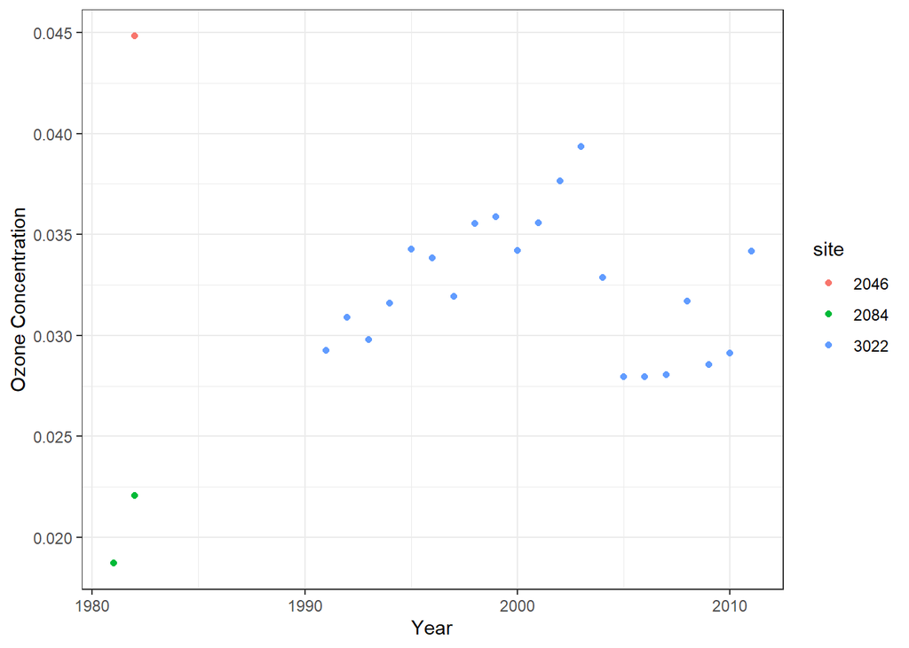

```r
require(ggplot2)
o3summarize_adm <- function(x){
  x$yr<- str_extract(x$date,"\\d{4}")
  out <- group_by(x, site = as.factor(site), Year = as.factor(yr)) %>%
  summarize(o3_annual_mean = mean(o3, na.rm = TRUE))
}
adm <- daily.site %>%
  filter(`County Name` == "Merced") %>%
  o3summarize_adm()
adm$Year<-as.double(as.character(adm$Year))
ggplot(adm, aes(x = Year, y = o3_annual_mean, color = site))+
         geom_point()+
  theme_bw()+
  ylab("Ozone Concentration")
```

```r
adm
```

```
## # A tibble: 24 x 3
## # Groups:   site [3]
##    site   Year o3_annual_mean
##    <fct> <dbl>          <dbl>
##  1 2046   1982         0.0448
##  2 2084   1981         0.0187
##  3 2084   1982         0.0221
##  4 3022   1991         0.0293
##  5 3022   1992         0.0309
##  6 3022   1993         0.0298
##  7 3022   1994         0.0316
##  8 3022   1995         0.0343
##  9 3022   1996         0.0338
## 10 3022   1997         0.0319
## # ... with 14 more rows
```

### 13. Fit a loess model to daily mean o3 for Merced County over the complete time series. Use daily mean o3 as the response and time as the predictor. Plot the resulting model on a scatter plot of mean o3 vs time.

```r
dmean <- daily.site %>%
  filter(`County Name` == "Merced")
x <- dmean$date
y<- dmean$o3

dmean.l <- loess(y~as.numeric(x), degree = 1, span = 0.05)
dmean.l
```

```
## Call:
## loess(formula = y ~ as.numeric(x), span = 0.05, degree = 1)
##
## Number of Observations: 9113
## Equivalent Number of Parameters: 32.11
## Residual Standard Error: 0.01028
```

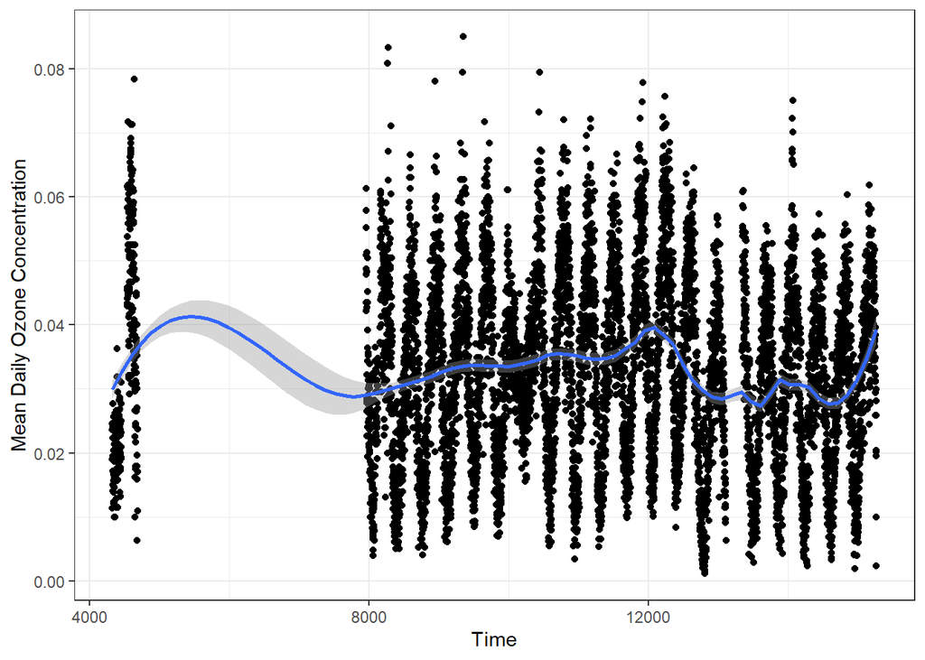

```r
ggplot(dmean, aes(x = as.numeric(date),y = o3))+
  geom_point()+
  geom_smooth(aes(x = as.numeric(date), y = o3),method = "loess", span = 0.25)+
  ylab("Mean Daily Ozone Concentration")+
  xlab("Time")+
  theme_bw()
```

This doesn’t appear to be a great model due to the missing data in the early 80’s, as well as because of the consistent seasonal pattern.

### 14. Document the long-term and seasonal trends in Merced County daily mean o3 using STL. Note that although the monitoring program aimed at collecting daily samples, there may have been occasional missing days in the record. Any missing values should be imputed using median polish with appropriate monthly or weekly averages.

```r
# dmean$date<-as.Date(dmean$date,, format = "%Y-%m-%d")
# dt <- rep(NA, 365*(2011-1981))
# k <- 0
# for (i in 1981:2011){
#   for (j in 1:365)+{
#     k <- k+1
#     temp <- as.numeric(format(dmean$date, "%d"))==j &
#       as.numeric(format(dmean$date, "%Y%")) ==i
#     if (sum(temp)>0)
#       dt[k]<-mean(dmean$o3[temp], na.rm=T)
#   }
# }
```

I understand I need to have a table with Rows of years and columns of days to use median polish to complete the table. Then I would use the stl function to create a model. I can’t figure out how to manipulate the date object to get what I want.